# Tipologia i cicle de vida de les dades: PRA2 - Titanic

Autors: Mónica Ortiz i Xavier Maltas

Decembre 2021

# 1 Introducció del dataset

El dataset escollit per a elaborar aquest anàlisi ha sigut **‘Titanic - Machine Learning from Disaster’**. Hi podreu accedir a través del següent enllaç a la pàgina web de Kaggle - https://www.kaggle.com/c/titanic

La informació que hi trobem es tracta d’un conjunt de dades associades a cada un dels passatgers del Titanic. A través d’aquestes generarem un model que ens permeti predir quin tipus de passatgers podrien sobreviure a la tragèdia tenint en compte els paràmetres o camps del dataset.

A continuació carregarem les dades i exposem una petita mostra del dataset.

```r
df.full <- read.csv("dataset/train.csv")
df.test <- read.csv("dataset/test.csv")
df.realSurvived <- read.csv("dataset/gender_submission.csv")
head(df.full)
```

```
##   PassengerId Survived Pclass
## 1           1        0      3
## 2           2        1      1
## 3           3        1      3
## 4           4        1      1
## 5           5        0      3
## 6           6        0      3
##                                                  Name    Sex Age SibSp Parch
## 1                             Braund, Mr. Owen Harris   male  22     1     0
## 2 Cumings, Mrs. John Bradley (Florence Briggs Thayer) female  38     1     0
## 3                              Heikkinen, Miss. Laina female  26     0     0
## 4        Futrelle, Mrs. Jacques Heath (Lily May Peel) female  35     1     0
## 5                            Allen, Mr. William Henry   male  35     0     0
## 6                                    Moran, Mr. James   male  NA     0     0
##             Ticket    Fare Cabin Embarked
## 1        A/5 21171  7.2500              S
## 2         PC 17599 71.2833   C85        C
## 3 STON/O2. 3101282  7.9250              S
## 4           113803 53.1000  C123        S
## 5           373450  8.0500              S
## 6           330877  8.4583              Q
```

# 2 Estudi de les dades d’entrada

Començarem realitzant un breu estudi de les dades d’entrada, ja que ens interessa obtenir una visió general de les dades que disposem en primera instància. És per aquest motiu que el primer pas és calcular el nombre de registres i la quantitat d’atributs que tenim al conjunt de dades d’entrenament.

El tipus de variable de cadascuna de les columnes és:

```r
print(paste("Dataset contains", nrow(df.full), "registers"))
```

```
## [1] "Dataset contains 891 registers"
```

```r
colnames(df.full)
```

```
##  [1] "PassengerId" "Survived"    "Pclass"      "Name"        "Sex"
##  [6] "Age"         "SibSp"       "Parch"       "Ticket"      "Fare"
## [11] "Cabin"       "Embarked"
```

```r
sapply(df.full,class)
```

```
## PassengerId    Survived      Pclass        Name         Sex         Age
##   "integer"   "integer"   "integer" "character" "character"   "numeric"
##       SibSp       Parch      Ticket        Fare       Cabin    Embarked
##   "integer"   "integer" "character"   "numeric" "character" "character"
```

```r
str(df.full)
```

```
## 'data.frame':    891 obs. of  12 variables:
##  $ PassengerId: int  1 2 3 4 5 6 7 8 9 10 ...
##  $ Survived   : int  0 1 1 1 0 0 0 0 1 1 ...
##  $ Pclass     : int  3 1 3 1 3 3 1 3 3 2 ...
##  $ Name       : chr  "Braund, Mr. Owen Harris" "Cumings, Mrs. John Bradley (Florence Briggs Thayer)" "Heikkinen, Miss. Laina" "Futrelle, Mrs. Jacques Heath (Lily May Peel)" ...
##  $ Sex        : chr  "male" "female" "female" "female" ...
##  $ Age        : num  22 38 26 35 35 NA 54 2 27 14 ...
##  $ SibSp      : int  1 1 0 1 0 0 0 3 0 1 ...
##  $ Parch      : int  0 0 0 0 0 0 0 1 2 0 ...
##  $ Ticket     : chr  "A/5 21171" "PC 17599" "STON/O2. 3101282" "113803" ...
##  $ Fare       : num  7.25 71.28 7.92 53.1 8.05 ...
##  $ Cabin      : chr  "" "C85" "" "C123" ...
##  $ Embarked   : chr  "S" "C" "S" "S" ...
```

```r
summary(df.full)
```

```
##   PassengerId       Survived          Pclass          Name
##  Min.   :  1.0   Min.   :0.0000   Min.   :1.000   Length:891
##  1st Qu.:223.5   1st Qu.:0.0000   1st Qu.:2.000   Class :character
##  Median :446.0   Median :0.0000   Median :3.000   Mode  :character
##  Mean   :446.0   Mean   :0.3838   Mean   :2.309
##  3rd Qu.:668.5   3rd Qu.:1.0000   3rd Qu.:3.000
##  Max.   :891.0   Max.   :1.0000   Max.   :3.000
##
##      Sex                 Age            SibSp           Parch
##  Length:891         Min.   : 0.42   Min.   :0.000   Min.   :0.0000
##  Class :character   1st Qu.:20.12   1st Qu.:0.000   1st Qu.:0.0000
##  Mode  :character   Median :28.00   Median :0.000   Median :0.0000
##                     Mean   :29.70   Mean   :0.523   Mean   :0.3816
##                     3rd Qu.:38.00   3rd Qu.:1.000   3rd Qu.:0.0000
##                     Max.   :80.00   Max.   :8.000   Max.   :6.0000
##                     NA's   :177
##     Ticket               Fare           Cabin             Embarked
##  Length:891         Min.   :  0.00   Length:891         Length:891
##  Class :character   1st Qu.:  7.91   Class :character   Class :character
##  Mode  :character   Median : 14.45   Mode  :character   Mode  :character
##                     Mean   : 32.20
##                     3rd Qu.: 31.00
##                     Max.   :512.33
##
```

Veiem que disposem d’un total de 891 registres que corresponen als viatgers i tripulació del Titanic, que es troben descrits per 12 atributs diferents. A continuació farem una definició més exhaustiva de cada camp.

| Variable | Description | Type |
| --- | --- | --- |
| PassengerId | ID del passatger | Integer |
| Pclass | Classe en la qual viatjava el passatger | Integer |
| Name | Nom del passatger | String |
| Sex | Gènere del passatger | String |
| Age | Edat del passatger | Numeric |
| SibSp | Factor que indicia el nombre de germans/parella que hi havia a bord (Sibilings/Spouses) | Integer |
| Parch | Factor que indica el nombre de pares/fills que hi havia a abord (Parents/Children) | Integer |
| Ticket | ID del tiquet | String |
| Fare | Valor del tiquet | Numeric |
| Cabin | Cabina assignada al passatger | String |
| Embarked | Factor que indica a on va embarcar el passatger | String |
| Survived | Factor que indica si va sobreviure o no | Integer |

# 3 Anàlisi descriptiva i correlacions

Sempre és important elaborar un anàlisi sobre les dades per poder observar algun tipus de correlació, ja que d’aquestes dependran les conclusions finals.

Ens recolzarem a un conjunt de processos gràfics que ens ajudaran de forma visual a reconèixer com es distribueixen alguns dels paràmetres corresponents als registres del dataset inicial. Farem ús de les llibreries **ggplot2**, **grid**, **gridExtra** per a executar aquesta tasca.

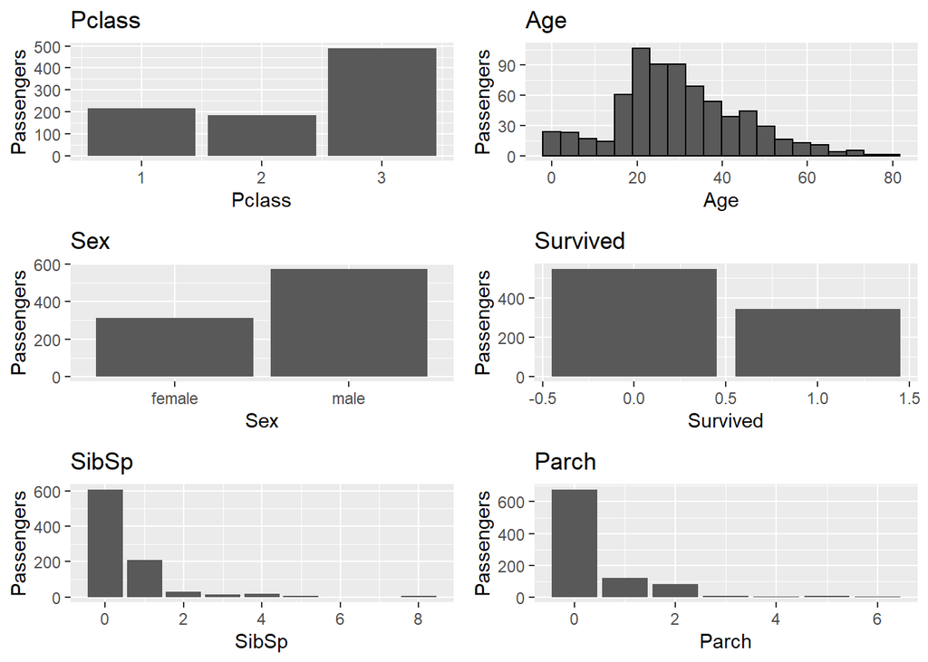

```r
plotbyClass<-ggplot(df.full,aes(Pclass))+geom_bar() +labs(x="Pclass", y="Passengers")+ guides(fill=guide_legend(title=""))+ggtitle("Pclass")
#plotbyClass

plotbyAge<-ggplot(df.full,aes(Age))+geom_histogram(bins=20, colour="black") +labs(x="Age", y="Passengers")+ guides(fill=guide_legend(title=""))+ggtitle("Age")
#plotbyAge

plotbySex<-ggplot(df.full,aes(Sex))+geom_bar() +labs(x="Sex", y="Passengers")+ guides(fill=guide_legend(title=""))+ggtitle("Sex")
#plotbySex

plotbySurvived<-ggplot(df.full,aes(Survived))+geom_bar() +labs(x="Survived", y="Passengers")+ guides(fill=guide_legend(title=""))+ggtitle("Survived")
#plotbySurvived
#grid.arrange(plotbyClass,plotbyAge,plotbySex,plotbySurvived,ncol=2)

plotbySibSp<-ggplot(df.full,aes(SibSp))+geom_bar() + labs(x="SibSp", y="Passengers")+ guides(fill=guide_legend(title=""))+ggtitle("SibSp")
#plotbySibSp

plotbyParch<-ggplot(df.full,aes(Parch))+geom_bar() + labs(x="Parch", y="Passengers")+ guides(fill=guide_legend(title=""))+ggtitle("Parch")
#plotbyParch

grid.arrange(plotbyClass,plotbyAge,plotbySex,plotbySurvived,plotbySibSp,plotbyParch,ncol=2)
```

Un cop observada la distribució de les anteriors variables, ens interessa descriure quina és la relació que hi ha entre cadascun d’aquests valors amb la supervivència. És per aquest motiu, que realitzarem uns gràfics similars als anteriors, però superposant la proporció de supervivents en cada un dels paràmetres.

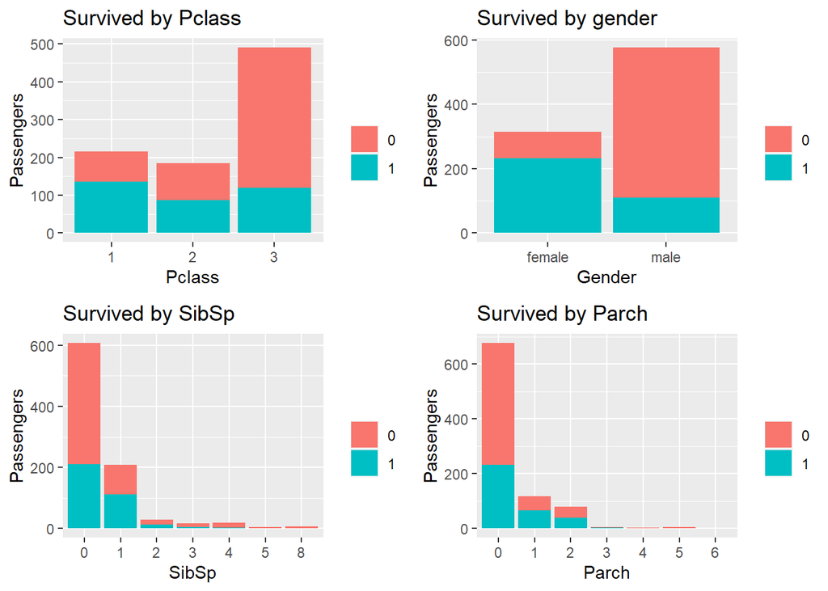

```r
survivedbyClass<-ggplot(df.full,aes(x=(as.factor(Pclass)), fill=(as.factor(Survived))))+geom_bar()+labs(x="Pclass", y="Passengers")+ guides(fill=guide_legend(title=""))+ggtitle("Survived by Pclass")
#survivedbyClass

survivedbySex <- ggplot(df.full, aes(x=(as.factor(Sex)), fill=(as.factor(Survived))))+geom_bar()+labs(x="Gender", y="Passengers")+ guides(fill=guide_legend(title=""))+ggtitle("Survived by gender")
#survivedbySex

survivedbySibSp <- ggplot(df.full, aes(x=(as.factor(SibSp)), fill=(as.factor(Survived))))+geom_bar()+labs(x="SibSp", y="Passengers")+ guides(fill=guide_legend(title=""))+ggtitle("Survived by SibSp")
#survivedbySibSp

survivedbyParch <- ggplot(df.full, aes(x=(as.factor(Parch)), fill=(as.factor(Survived))))+geom_bar()+labs(x="Parch", y="Passengers")+ guides(fill=guide_legend(title=""))+ggtitle("Survived by Parch")
#survivedbyParch

grid.arrange(survivedbyClass,survivedbySex,survivedbySibSp,survivedbyParch,ncol=2)
```

A la primera gràfica podem observar que més o menys van sobreviure la mateixa quantitat de persones dels diferents tipus de classes, tot i que la proporció és bastant més favorable com millor era la classe. Pel que fa al gènere, observem que la quantitat de dones respecte homes passatgers era inferior, tot i que pel que fa a en termes de supervivència, les dones van tenir un percentatge molt més elevat. Finalment, a les dues últimes gràfiques, podem extreure que el fet de tenir familiars a bord, no té una relació directa amb la supervivència.

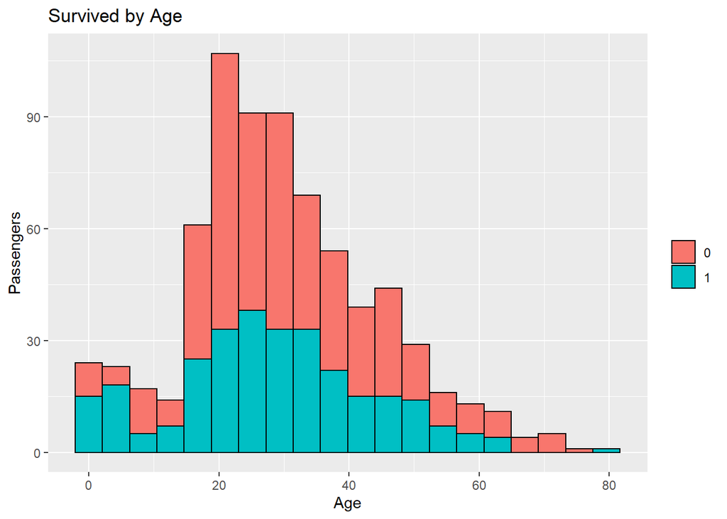

```r
survivedbyAge<-ggplot(df.full, aes(x=Age, fill=(as.factor(Survived))))+geom_histogram(bins=20, colour="black")+labs(x="Age", y="Passengers")+ guides(fill=guide_legend(title=""))+ggtitle("Survived by Age")
survivedbyAge
```

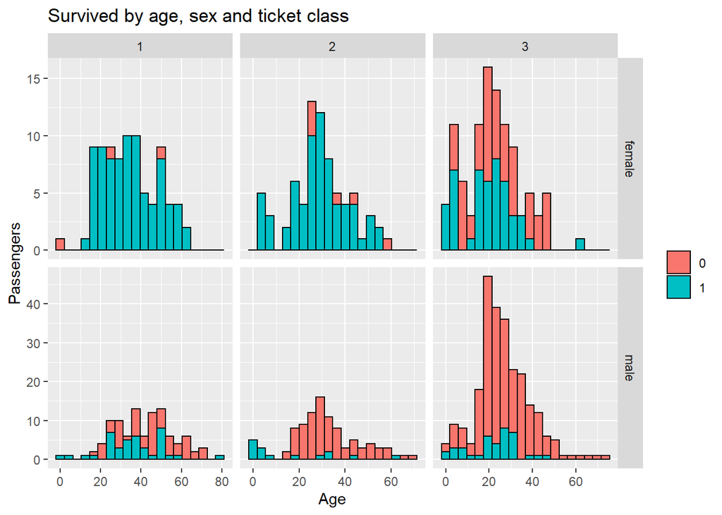

```r
survivedbyAgeSexClass<-ggplot(df.full, aes(x=Age, fill=(as.factor(Survived))))+geom_histogram(bins=20, colour="black")+ facet_grid(Sex~Pclass, scales="free")+labs(x="Age", y="Passengers")+guides(fill=guide_legend(title=""))+ggtitle("Survived by age, sex and ticket class")
survivedbyAgeSexClass
```

# 4 Integració i selecció de les dades d’interès a analitzar.

Tenint en compte l’estudi visual anterior, hem cregut oportú reduir la quantitat de variables de la mostra amb les que treballar, i només disposar d’aquelles que hem observat que tenen una major rellevància. Les variables que mantenim per fer el posterior anàlisi de les dades són les següents:

- Survived
- Pclass
- Sex
- Age
- Sibsp
- Parch
- Fare

```
##   Survived Pclass    Sex Age SibSp Parch    Fare
## 1        0      3   male  22     1     0  7.2500
## 2        1      1 female  38     1     0 71.2833
## 3        1      3 female  26     0     0  7.9250
## 4        1      1 female  35     1     0 53.1000
## 5        0      3   male  35     0     0  8.0500
## 6        0      3   male  NA     0     0  8.4583
```

La variable ‘name’, podria tenir algun tipus de relació amb el títol nobiliari, però finalment no la mantenim, ja que no és una variable que importi a l’hora de predir si un passatger sobreviu o no.

# 5 Neteja de dades

## 5.1 Gestió dels elements buits

Veiem que la variable que conté valors nuls és ‘Age’, decidim rellevar aquests valors nuls per la mitjana total de la variable:

```r
#Check NA values
colSums(is.na(df))
```

```
## Survived   Pclass      Sex      Age    SibSp    Parch     Fare
##        0        0        0      177        0        0        0
```

```r
colSums(df=="")
```

```
## Survived   Pclass      Sex      Age    SibSp    Parch     Fare
##        0        0        0       NA        0        0        0
```

```r
#All NA values of 'Age' var to mean age
mean(df$Age)
```

```
## [1] NA
```

```r
df$Age[is.na(df$Age)] <- mean(df$Age,na.rm=T)

colSums(is.na(df))
```

```
## Survived   Pclass      Sex      Age    SibSp    Parch     Fare
##        0        0        0        0        0        0        0
```

## 5.2 Identificació i tractament de valors extrems.

Les variables que analitzarem del dataframe són ‘Age’ i ‘Fare’, ja que són les úniques pròpiament numèriques. Per observar els outliers realitzarem gràfics de caixes o boxplots.

### 5.2.1 Identificació outliers

#### 5.2.1.1 Age

Començarem per la variable ‘Age’, veient estadístiques de la variable i grafiant els boxplots.

```r
#'Age'
summary(df$Age)
```

```
##    Min. 1st Qu.  Median    Mean 3rd Qu.    Max.
##    0.42   22.00   29.70   29.70   35.00   80.00
```

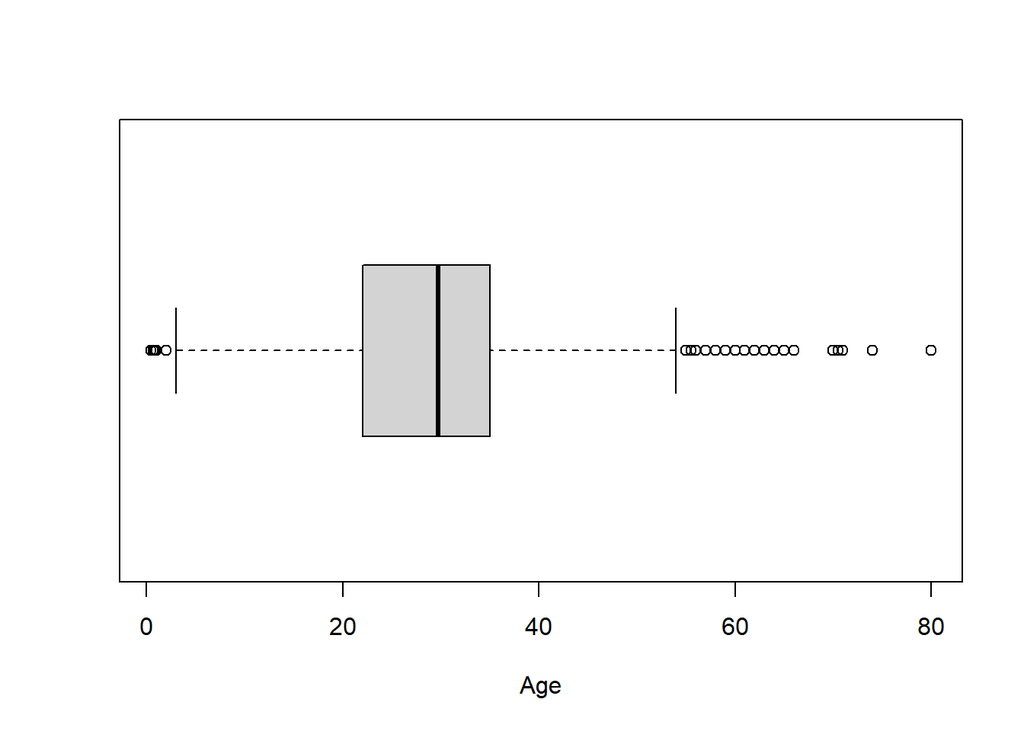

```r
age.bp <- boxplot(df$Age, xlab = "Age", horizontal=TRUE)
```

```r
ageOutliersAge <- age.bp$out
ageOutliersAge
```

```
##  [1]  2.00 58.00 55.00  2.00 66.00 65.00  0.83 59.00 71.00 70.50  2.00 55.50
## [13]  1.00 61.00  1.00 56.00  1.00 58.00  2.00 59.00 62.00 58.00 63.00 65.00
## [25]  2.00  0.92 61.00  2.00 60.00  1.00  1.00 64.00 65.00 56.00  0.75  2.00
## [37] 63.00 58.00 55.00 71.00  2.00 64.00 62.00 62.00 60.00 61.00 57.00 80.00
## [49]  2.00  0.75 56.00 58.00 70.00 60.00 60.00 70.00  0.67 57.00  1.00  0.42
## [61]  2.00  1.00 62.00  0.83 74.00 56.00
```

Observem que tots aquells valors iguals o inferiors a 2 o igual i superiors a 55 són considerats outliers. A continuació realitzarem diverses comprovacions per tal de validar aquests resultats.

```r
#Aquesta primera verificació s'ha tret de la següent font de dades:
#https://www.adictosaltrabajo.com/2019/11/28/deteccion-y-reemplazo-de-outliers-con-r/

quantile(df$Age)
```

```
##       0%      25%      50%      75%     100%
##  0.42000 22.00000 29.69912 35.00000 80.00000
```

```r
iAge <- IQR(df$Age)
iAge
```

```
## [1] 13
```

```r
#Outliers per damunt del bigotis:
#Q3 + 1,5 x IQR
out_upp_Age <- 35 + 1.5 * iAge
out_upp_Age
```

```
## [1] 54.5
```

```r
#Outliers per sota del bigotis:
#Q1 - 1,5 x IQR
out_low_Age <- 22 - 1.5 * iAge
out_low_Age
```

```
## [1] 2.5
```

```r
# Criteri +/-2SD -
#Hem utilitzat les següents pàgines web per guiar-nos amb aquest criteri:
#https://machinelearningmastery.com/how-to-use-statistics-to-identify-outliers-in-data/
#https://www.diegocalvo.es/calculo-de-outliers-en-r-distancia-de-gauss-y-de-mahalanobis/
#http://r-statistics.co/Outlier-Treatment-With-R.html

mean<-mean(df$Age)
sd<-sd(df$Age)
cutoff<- sd*2
print(paste("Cutoff: ",cutoff))
```

```
## [1] "Cutoff:  26.0040304520058"
```

```r
upperBoundaryAge <- mean+cutoff
lowerBoundaryAge <- mean-cutoff
print(paste("Range: [", lowerBoundaryAge, ",",upperBoundaryAge, "]"))
```

```
## [1] "Range: [ 3.69508719505306 , 55.7031480990646 ]"
```

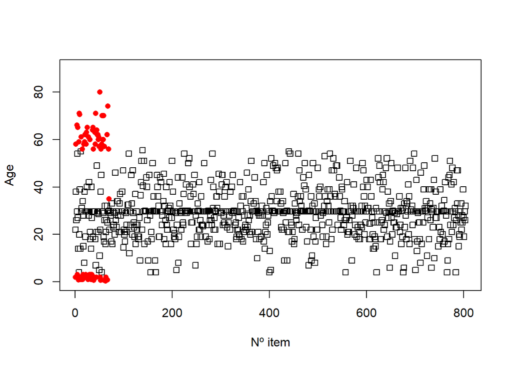

```r
#Graficar els outliers amb gràfic de punts:
age.outlier.Age <- abs(scale(df$Age)) > 2
outliers <- na.omit(rbind(df[age.outlier.Age,],df$Age))
dataSetWOutliers <- df[!(df$Age %in% outliers$Age),]
plot(dataSetWOutliers$Age, pch=0, xlab="Nº item", ylab="Age",ylim=c(0,90))
points(outliers$Age, pch=16, col="red")
```

Un cop realitzades les comprovacions a través de dos criteris diferents, podem veure que els resultats previament obtinguts concorden amb el que hem obtingut a les validacions.

#### 5.2.1.2 Fare

Amb la variable ‘Fare’ seguirem els mateixos passos que hem realitzat amb l’anterior.

```r
#Identificació outliers variable 'Fare':
#Analitzar estadístiques de 'Fare':
summary(df$Fare)
```

```
##    Min. 1st Qu.  Median    Mean 3rd Qu.    Max.
##    0.00    7.91   14.45   32.20   31.00  512.33
```

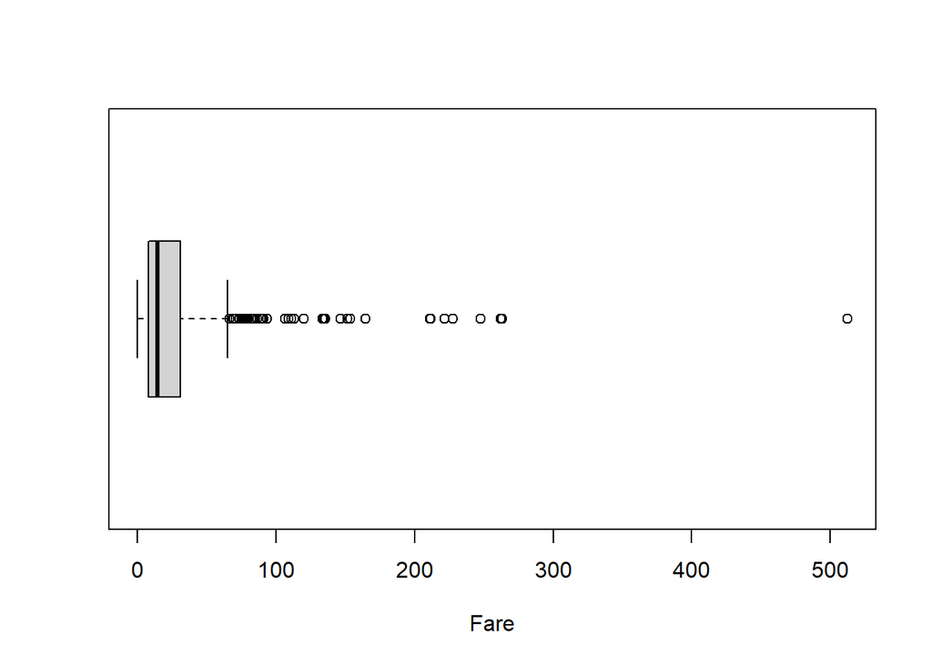

```r
#Graficar els boxplots per veure els outliers:
fare.bp <- boxplot(df$Fare, xlab = "Fare", horizontal=TRUE)
```

```r
fareOutliers <- fare.bp$out
fareOutliers
```

```
##   [1]  71.2833 263.0000 146.5208  82.1708  76.7292  80.0000  83.4750  73.5000
##   [9] 263.0000  77.2875 247.5208  73.5000  77.2875  79.2000  66.6000  69.5500
##  [17]  69.5500 146.5208  69.5500 113.2750  76.2917  90.0000  83.4750  90.0000
##  [25]  79.2000  86.5000 512.3292  79.6500 153.4625 135.6333  77.9583  78.8500
##  [33]  91.0792 151.5500 247.5208 151.5500 110.8833 108.9000  83.1583 262.3750
##  [41] 164.8667 134.5000  69.5500 135.6333 153.4625 133.6500  66.6000 134.5000
##  [49] 263.0000  75.2500  69.3000 135.6333  82.1708 211.5000 227.5250  73.5000
##  [57] 120.0000 113.2750  90.0000 120.0000 263.0000  81.8583  89.1042  91.0792
##  [65]  90.0000  78.2667 151.5500  86.5000 108.9000  93.5000 221.7792 106.4250
##  [73]  71.0000 106.4250 110.8833 227.5250  79.6500 110.8833  79.6500  79.2000
##  [81]  78.2667 153.4625  77.9583  69.3000  76.7292  73.5000 113.2750 133.6500
##  [89]  73.5000 512.3292  76.7292 211.3375 110.8833 227.5250 151.5500 227.5250
##  [97] 211.3375 512.3292  78.8500 262.3750  71.0000  86.5000 120.0000  77.9583
## [105] 211.3375  79.2000  69.5500 120.0000  93.5000  80.0000  83.1583  69.5500
## [113]  89.1042 164.8667  69.5500  83.1583
```

```r
#Fare outliers:
quantile(df$Fare)
```

```
##       0%      25%      50%      75%     100%
##   0.0000   7.9104  14.4542  31.0000 512.3292
```

```r
iFare <- IQR(df$Fare)
iFare
```

```
## [1] 23.0896
```

```r
#Outliers per damunt del bigotis:
#Q3 + 1,5 x IQR
out_upp_Fare <- 31 + 1.5 * iFare
out_upp_Fare
```

```
## [1] 65.6344
```

```r
#Outliers per sota del bigotis:
#Q1 - 1,5 x IQR
out_low_Fare <- 7.91 - 1.5 * iFare
out_low_Fare
```

```
## [1] -26.7244
```

```r
#En aquest cas el valor més baix és negatiu i com que no hi ha valors 'Fare' per sota de zero, vol dir que no hi ha outliers per sota del bigotis.
```

```r
# Criterio +/-2SD:
mean<-mean(df$Fare)
sd<-sd(df$Fare)
cutoff<- sd*2
print(paste("Cutoff: ",cutoff))
```

```
## [1] "Cutoff:  99.3868571943618"
```

```r
upperBoundaryAge <- mean+cutoff
lowerBoundaryAge <- mean-cutoff
print(paste("Range: [", lowerBoundaryAge, ",",upperBoundaryAge, "]"))
```

```
## [1] "Range: [ -67.1826492257872 , 131.591065162936 ]"
```

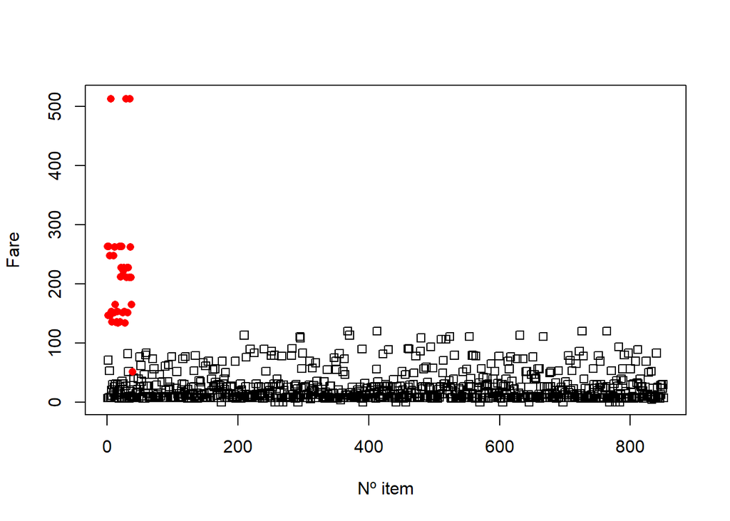

```r
fare.outlier <- abs(scale(df$Fare)) > 2
outliers <- na.omit(rbind(df[fare.outlier,],df$Fare))
dataSetWOutliers <- df[!(df$Fare %in% outliers$Fare),]
plot(dataSetWOutliers$Fare, pch=0, xlab="Nº item", ylab="Fare", ylim = c(0,515))
points(outliers$Fare, pch=16, col="red")
```

### 5.2.2 Tractament outliers

Un cop observat els resultats dels outliers de les variables ‘Age’ i ‘Fare’, hem arribat al següent plantejament. Pel que fa a la variable ‘Age’, hem decidit eliminar aquests registres del dataframe, ja que és una quantitat molt poc rellevant i generen soroll i desviacions, cosa que no ens interessa a l’hora d’entrenar el nostre model predictiu.

```r
library('dplyr')
#Eliminem els outliers variable Age:
df.clean <- df %>% filter(Age > 2 & Age < 55)
head(df.clean)
```

```
##   Survived Pclass    Sex      Age SibSp Parch    Fare
## 1        0      3   male 22.00000     1     0  7.2500
## 2        1      1 female 38.00000     1     0 71.2833
## 3        1      3 female 26.00000     0     0  7.9250
## 4        1      1 female 35.00000     1     0 53.1000
## 5        0      3   male 35.00000     0     0  8.0500
## 6        0      3   male 29.69912     0     0  8.4583
```

# 6 Anàlisi de les dades i representació dels resultats a partir de taules i gràfiques.

Hem decidit juntar el punt 4 i 5 perquè a mesura que anem fent anàlisis i prediccions del dataset anem mostrant les gràfiques corresponents d’aquella predicció en contret. D’aquesta manera el codi i els gràfics estan millor organitzats i s’entèn millor.

Inicialment, hem creat unes *dummy variables* amb els valors de ‘Sex’ transformant-les en valors numèrics i així poder-les utilitzar per realitzar prediccions.

```r
#Sex to dummy variables
sexfactor = factor(df.clean$Sex)
dummies.sex = model.matrix(~sexfactor)
RL.df <- data.frame(df.clean, dummies.sex[,2])
RL.df$dummies.sex <- RL.df$dummies.sex...2.
RL.df$dummies.sex...2. <- NULL

#Clean Test DF, per fer les prediccions necessitarem el datset de test, que hem carregat al començament de la pràctica, i també s'ha de netejar de la mateixa forma que el dataset de 'train':
df.test <- select(df.test, Pclass, Sex, Age, SibSp, Parch, Fare)
colSums(is.na(df.test))
```

```
## Pclass    Sex    Age  SibSp  Parch   Fare
##      0      0     86      0      0      1
```

```r
colSums(df.test=="")
```

```
## Pclass    Sex    Age  SibSp  Parch   Fare
##      0      0     NA      0      0     NA
```

```r
df.test$Age[is.na(df.test$Age)] <- mean(df.test$Age,na.rm=T)
df.test$Fare[is.na(df.test$Fare)] <- 0 #If this value is a NA, we set it to 0. We can not know which was its price.
```

## 6.1 Model de regressió logística

El primer model predictiu que hem decidit utilitzar és el de la regressió logística. Aquest model fa ús de la funció Sigmoide que ens permetrà classificar diferents valors d’entrada depenent d’un valor de tall.

```r
#Hem començat fent un model de regressió logística representat dins una funció Sigmoide:

#RL - Model de regressió logistica
if (!require('caret')) install.packages('caret'); library('caret')
#Creating Sigmoide function
RL.model <- glm(Survived ~ Pclass + dummies.sex +Age + SibSp + Parch + Fare, data=RL.df, family=binomial) #https://stats.idre.ucla.edu/r/dae/logit-regression/
summary(RL.model)
```

```
##
## Call:
## glm(formula = Survived ~ Pclass + dummies.sex + Age + SibSp +
##     Parch + Fare, family = binomial, data = RL.df)
##
## Deviance Residuals:
##     Min       1Q   Median       3Q      Max
## -2.3554  -0.5638  -0.4233   0.5882   2.4277
##
## Coefficients:
##              Estimate Std. Error z value Pr(>|z|)
## (Intercept)  4.718565   0.578042   8.163 3.27e-16 ***
## Pclass      -1.058844   0.144491  -7.328 2.33e-13 ***
## dummies.sex -2.838756   0.209857 -13.527  < 2e-16 ***
## Age         -0.033450   0.009884  -3.384 0.000714 ***
## SibSp       -0.323138   0.114260  -2.828 0.004683 **
## Parch       -0.155491   0.123230  -1.262 0.207024
## Fare         0.003432   0.002512   1.366 0.171898
## ---
## Signif. codes:  0 '***' 0.001 '**' 0.01 '*' 0.05 '.' 0.1 ' ' 1
##
## (Dispersion parameter for binomial family taken to be 1)
##
##     Null deviance: 1096.19  on 824  degrees of freedom
## Residual deviance:  719.75  on 818  degrees of freedom
## AIC: 733.75
##
## Number of Fisher Scoring iterations: 5
```

Un cop disposem del model predictiu de regressió logística, ens disposem a realitzar les prediccions.

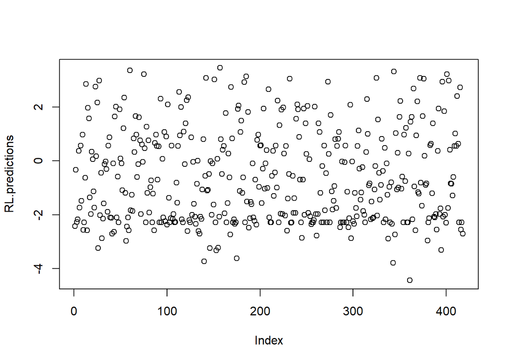

```r
#Regressió Logística del dataset de test, df.test:
RL.df.test <- df.test
sexfactor.test = factor(RL.df.test$Sex)
dummies.sex.test = model.matrix(~sexfactor.test)
RL.df.test <- data.frame(RL.df.test, dummies.sex.test[,2])
RL.df.test$dummies.sex <- RL.df.test$dummies.sex.test...2.
RL.df.test$dummies.sex.test...2. <- NULL

#Fem les prediccions
RL.predictions <- predict(RL.model, RL.df.test)
#View(RL.predictions)
plot(RL.predictions)
```

Apliquem la funció Sigmoide per normalitzar els valors.

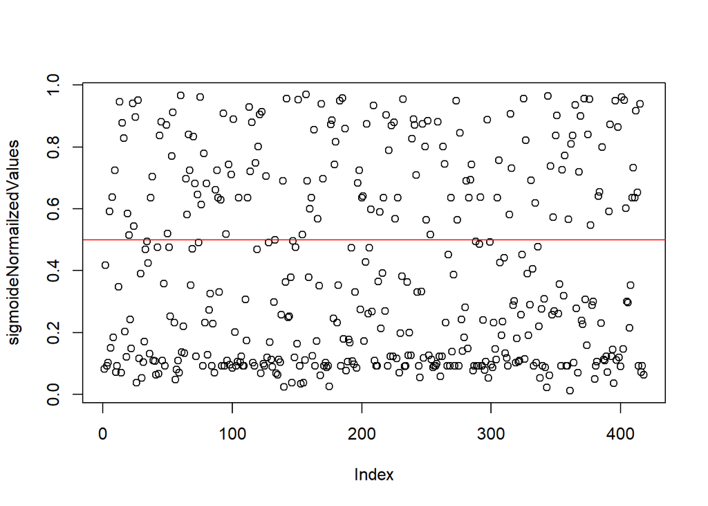

```r
#Apply Sigmoide function:
sigmoideFunction <- function(x){1/(1+exp(-x))}
sigmoideNormailzedValues <- sapply(RL.predictions, sigmoideFunction)
plot(sigmoideNormailzedValues)
abline(h=0.5, col="red")
```

A continuació separem els registres depenent del valor de tall 0.5. Els que són superior són considerats supervivents, mentre que els que tenen un valor inferior, no.

```r
#Computing survived parameter:
RL.survived <- ifelse(sigmoideNormailzedValues > 0.5, 1,0)
#View(RL.survived)
RL.df.test$predictedValue <- sigmoideNormailzedValues
RL.df.test$PredictedSurvived <- RL.survived
```

Seguidament, realitzem la comparativa entre els valors testejats i els valors reals dels mateixos registres.

```r
#Test with the real results
RL.df.test$RealSurvived <- df.realSurvived$Survived
head(RL.df.test)
```

```
##   Pclass    Sex  Age SibSp Parch    Fare dummies.sex predictedValue
## 1      3   male 34.5     0     0  7.8292           1     0.08136890
## 2      3 female 47.0     1     0  7.0000           0     0.41842378
## 3      2   male 62.0     0     0  9.6875           1     0.09291486
## 4      3   male 27.0     0     0  8.6625           1     0.10246280
## 5      3 female 22.0     1     1 12.2875           0     0.59137769
## 6      3   male 14.0     0     0  9.2250           1     0.15015692
##   PredictedSurvived RealSurvived
## 1                 0            0
## 2                 0            1
## 3                 0            0
## 4                 0            0
## 5                 1            1
## 6                 0            0
```

Per acabar i veure l’exactitud del model creat, realitzem la matriu de confusió.

```r
#Confusion Matrix
PredictedSurvivedFactor <- factor(RL.df.test$PredictedSurvived)
RealSurvivedFactor <- factor(RL.df.test$RealSurvived)
RL.confusionMatrix <- confusionMatrix(PredictedSurvivedFactor,RealSurvivedFactor)
RL.confusionMatrix
```

```
## Confusion Matrix and Statistics
##
##           Reference
## Prediction   0   1
##          0 258  10
##          1   8 142
##
##                Accuracy : 0.9569
##                  95% CI : (0.9328, 0.9743)
##     No Information Rate : 0.6364
##     P-Value [Acc > NIR] : <2e-16
##
##                   Kappa : 0.9067
##
##  Mcnemar's Test P-Value : 0.8137
##
##             Sensitivity : 0.9699
##             Specificity : 0.9342
##          Pos Pred Value : 0.9627
##          Neg Pred Value : 0.9467
##              Prevalence : 0.6364
##          Detection Rate : 0.6172
##    Detection Prevalence : 0.6411
##       Balanced Accuracy : 0.9521
##
##        'Positive' Class : 0
##
```

```r
#Aquest model té un exactitud del 95% segons la matriu de confusió.

#Creació del fitxer csv resultant
dir.create("analyzedDataset")
write.csv(RL.df.test,"analyzedDataset\\RLDataframe.csv", row.names = TRUE)
```

Observem que l’exactitud del model de regressió logística és del 95%.

## 6.2 Model arbre de decisió

```r
#DT - Decision Tree
DT.df <- df.clean
summary(DT.df)
```

```
##     Survived          Pclass          Sex                 Age
##  Min.   :0.0000   Min.   :1.000   Length:825         Min.   : 3.00
##  1st Qu.:0.0000   1st Qu.:2.000   Class :character   1st Qu.:22.00
##  Median :0.0000   Median :3.000   Mode  :character   Median :29.70
##  Mean   :0.3806   Mean   :2.342                      Mean   :28.88
##  3rd Qu.:1.0000   3rd Qu.:3.000                      3rd Qu.:34.00
##  Max.   :1.0000   Max.   :3.000                      Max.   :54.00
##      SibSp            Parch             Fare
##  Min.   :0.0000   Min.   :0.0000   Min.   :  0.000
##  1st Qu.:0.0000   1st Qu.:0.0000   1st Qu.:  7.896
##  Median :0.0000   Median :0.0000   Median : 13.417
##  Mean   :0.5079   Mean   :0.3576   Mean   : 31.484
##  3rd Qu.:1.0000   3rd Qu.:0.0000   3rd Qu.: 30.071
##  Max.   :8.0000   Max.   :6.0000   Max.   :512.329
```

Per fer l’anàlisi de prediccions amb un model d’arbre de decisió necessitem el paquet **rpart** i per representar els resultats el **rpart.plot**.

```r
if (!require('rpart')) install.packages('rpart'); library('rpart')
```

```r
if (!require('rpart.plot')) install.packages('rpart.plot'); library('rpart.plot')
DT.rpart.df <- DT.df
DT.rpart.df.test <- df.test
```

Els models predictius de tipus arbre de decisió estan formats per un conjunt de nodes (node de decisió) que efectuen una pregunta sobre el valor d’un atribut. Les diferents respostes que s’hi poden anar donant generen nous nodes de decisió construint un arbre. Al final de cada camí recorregut al llarg de l’arbre hi trobarem el valor predit.

```r
#Model creation
DT.rpart.model <- rpart(Survived ~ Pclass + Sex + Age + SibSp + Parch + Fare, data=DT.rpart.df)
summary(DT.rpart.model)
```

```
## Call:
## rpart(formula = Survived ~ Pclass + Sex + Age + SibSp + Parch +
##     Fare, data = DT.rpart.df)
##   n= 825
##
##           CP nsplit rel error    xerror       xstd
## 1 0.30588709      0 1.0000000 1.0033980 0.01720340
## 2 0.08189937      1 0.6941129 0.6979441 0.03488181
## 3 0.03250823      2 0.6122135 0.6170820 0.03305220
## 4 0.02146721      3 0.5797053 0.5913688 0.03197411
## 5 0.01467075      4 0.5582381 0.6006723 0.03390141
## 6 0.01042866      5 0.5435673 0.6021599 0.03442475
## 7 0.01000000      7 0.5227100 0.6024241 0.03478825
##
## Variable importance
##    Sex   Fare Pclass  Parch    Age  SibSp
##     46     20     17      7      7      3
##
## Node number 1: 825 observations,    complexity param=0.3058871
##   mean=0.3806061, MSE=0.2357451
##   left son=2 (531 obs) right son=3 (294 obs)
##   Primary splits:
##       Sex    splits as  RL,           improve=0.30588710, (0 missing)
##       Pclass < 2.5      to the right, improve=0.11577020, (0 missing)
##       Fare   < 10.48125 to the left,  improve=0.09536378, (0 missing)
##       Age    < 6.5      to the right, improve=0.01965933, (0 missing)
##       Parch  < 0.5      to the left,  improve=0.01779026, (0 missing)
##   Surrogate splits:
##       Parch < 0.5      to the left,  agree=0.686, adj=0.119, (0 split)
##       Fare  < 77.6229  to the left,  agree=0.675, adj=0.088, (0 split)
##       Age   < 15.5     to the right, agree=0.652, adj=0.024, (0 split)
##       SibSp < 0.5      to the left,  agree=0.647, adj=0.010, (0 split)
##
## Node number 2: 531 observations,    complexity param=0.03250823
##   mean=0.180791, MSE=0.1481056
##   left son=4 (430 obs) right son=5 (101 obs)
##   Primary splits:
##       Pclass < 1.5      to the right, improve=0.080394060, (0 missing)
##       Fare   < 26.26875 to the left,  improve=0.071736170, (0 missing)
##       Age    < 13       to the right, improve=0.035536070, (0 missing)
```

[output cut: 70 more lines]

```
##       Age   < 43       to the right, improve=0.015786380, (0 missing)
##       Parch < 0.5      to the right, improve=0.001053629, (0 missing)
##       SibSp < 0.5      to the left,  improve=0.000864946, (0 missing)
##
## Node number 12: 25 observations
##   mean=0.12, MSE=0.1056
##
## Node number 13: 110 observations
##   mean=0.5727273, MSE=0.2447107
##
## Node number 22: 79 observations
##   mean=0.3797468, MSE=0.2355392
##
## Node number 23: 13 observations
##   mean=0.8461538, MSE=0.1301775
```

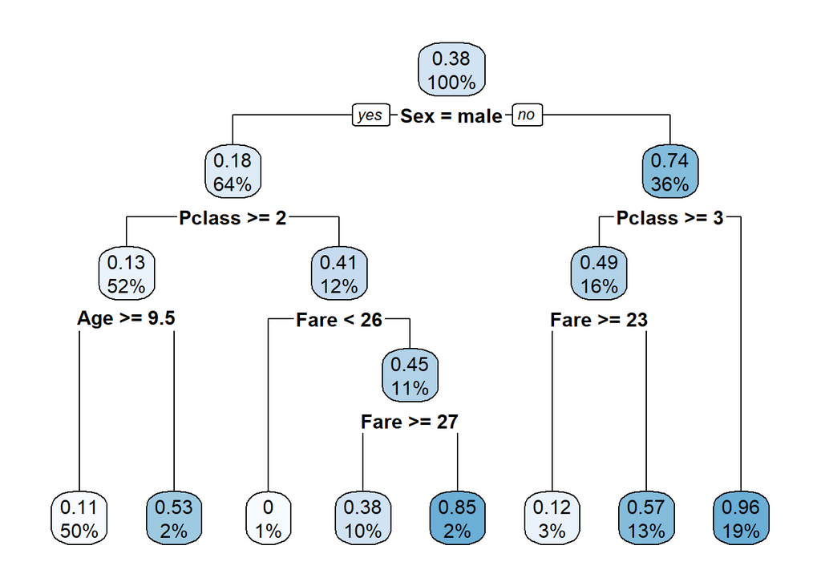

```r
rpart.plot(DT.rpart.model)
```

Un cop disposem del model d’arbre de decisió, ens disposem a realitzar les prediccions.

```r
#Predictions
DT.rpart.predictions <- predict(DT.rpart.model, DT.rpart.df.test)
#View(DT.rpart.predictions)
```

A continuació separem els registres depenent del valor de tall 0.5. Els que són superior són considerats supervivents, mentre que els que tenen un valor inferior, no.

```r
DT.rpart.survived <- ifelse(DT.rpart.predictions > 0.5, 1,0)
#View(DT.rpart.survived)
```

Seguidament, realitzem la comparativa entre els valors testejats i els valors reals dels mateixos registres.

```r
#Adding columns for the comparison:
DT.rpart.predictions <- factor(DT.rpart.predictions)
DT.rpart.df.test$predictedValue <- DT.rpart.predictions
DT.rpart.df.test$PredictedSurvived <- DT.rpart.survived
DT.rpart.df.test$RealSurvived <- df.realSurvived$Survived
head(DT.rpart.df.test)
```

```
##   Pclass    Sex  Age SibSp Parch    Fare    predictedValue PredictedSurvived
## 1      3   male 34.5     0     0  7.8292  0.11138014527845                 0
## 2      3 female 47.0     1     0  7.0000 0.572727272727273                 1
## 3      2   male 62.0     0     0  9.6875  0.11138014527845                 0
## 4      3   male 27.0     0     0  8.6625  0.11138014527845                 0
## 5      3 female 22.0     1     1 12.2875 0.572727272727273                 1
## 6      3   male 14.0     0     0  9.2250  0.11138014527845                 0
##   RealSurvived
## 1            0
## 2            1
## 3            0
## 4            0
## 5            1
## 6            0
```

Per acabar i veure l’exactitud del model creat, realitzem la matriu de confusió.

```r
#Confusion Matrix:

DT.rpart.predictedSurvived.factor <- factor(DT.rpart.df.test$PredictedSurvived)
DT.rpart.realSurvived.factor <- factor(DT.rpart.df.test$RealSurvived)

DT.rpart.confusionMatrix <- confusionMatrix(DT.rpart.predictedSurvived.factor,DT.rpart.realSurvived.factor)
DT.rpart.confusionMatrix
```

```
## Confusion Matrix and Statistics
##
##           Reference
## Prediction   0   1
##          0 251   6
##          1  15 146
##
##                Accuracy : 0.9498
##                  95% CI : (0.9242, 0.9686)
##     No Information Rate : 0.6364
##     P-Value [Acc > NIR] : < 2e-16
##
##                   Kappa : 0.8928
##
##  Mcnemar's Test P-Value : 0.08086
##
##             Sensitivity : 0.9436
##             Specificity : 0.9605
##          Pos Pred Value : 0.9767
##          Neg Pred Value : 0.9068
##              Prevalence : 0.6364
##          Detection Rate : 0.6005
##    Detection Prevalence : 0.6148
##       Balanced Accuracy : 0.9521
##
##        'Positive' Class : 0
##
```

```r
#Aquest model té un exactitud del 94% segons la matriu de confusió.

#Creació del fitxer csv resultant
write.csv(DT.rpart.df.test,"analyzedDataset\\DTrpartDataframe.csv", row.names = TRUE)
```

Observem que l’exactitud del model d’arbre de decisió és del 94%.

# 7 Resultats i conclusions

# 8 Taula de contribucions

| Contribucions | Firma |
| --- | --- |
| Investigació prèvia | Xavier Maltas i Mónica Ortiz |
| Redacció de les respostes | Xavier Maltas i Mónica Ortiz |
| Desenvolupament codi | Xavier Maltas i Mónica Ortiz |